# Wind and doldrum-like conditions for GBR bleaching mortality

Coverage audit and source decision for ERA5, eReefs, Sentinel-1 SAR, and Metop-B

# Decision

The linked Sentinel-1 SAR product should **not** be used to count calm days or reconstruct a full Q1 wind history. The eReefs daily wind forcing is retained for historical sensitivity analyses, but its 2024 value is explicitly partial. Metop-B is a useful independent offshore comparison, not a GBR-wide replacement.

The continuous AWS ERA5 extraction now passes the prespecified eReefs product check for both mean wind and the low-wind tail. ERA5 provides complete Q1 coverage for every event, including 2024, and should enter the formal BRMS/BRT candidate set as a compact mean-plus-calm pair. Predictive promotion still depends on the fixed outer folds; product agreement alone is not evidence that wind improves mortality prediction.

# What is available

The [IMOS Sentinel-1 SAR wind record](https://portal-beta.aodn.org.au/details/b02b929f-2caf-45d4-ac60-d4632b7ca0ca?tab=summary) contains calibrated 10-m neutral wind speed and direction at approximately 1-km resolution. The official metadata dates it from 23 October 2017, which already excludes the 2016 event. Its [daily gridded THREDDS archive](https://thredds.aodn.org.au/thredds/catalog/IMOS/SRS/Surface-Waves/SAR_Wind/DELAYED/GRIDDED/SENTINEL-1/catalog.html) combines only the satellite swaths present on each day; a nominal daily file is not a wall-to-wall daily observation.

The DMS eReefs GBR4 store contains `mean_wspeed`, `wspeed_u`, and `wspeed_v`. These are continuous model-forcing fields for complete Q1 periods in 2016, 2017, 2020, and 2022, but the public v2 record stops on 17 January 2024.

The adjacent IMOS Metop-B scatterometer archive spans every event from 2016 to 2024 and is calibrated against buoy winds. It has regular repeat sampling offshore, but valid coastal coverage is insufficient for the inshore programme.

# Sentinel-1 coverage audit

The audit queried all 91 Q1 2024 daily files on a 0.1-degree GBR grid while preserving the native swath gaps.

| Measure | Value |
| --- | --- |
| Mean GBR domain covered on a day | 3.9% |
| Median observed days per audit cell | 0 |
| Median observed days at a registry feature | 7 |
| Registry features with at least 10 observed days | 2346 / 7063 |

Seven observed days out of 91 cannot identify sustained calm spells. Using a wide spatial neighbourhood would increase counts by pooling different places, not by observing the same reef more often.

# Metop-B coverage at modelling reefs

Good-QC Metop-B observations within 30 km were aggregated to daily medians. A reef-year is called adequate only when at least 70% of Q1 days are represented.

| Programme | Model rows | Adequate coverage |
| --- | --- | --- |
| LTMP benthic | 199 | 60 / 199 (30%) |
| LTMP manta tow | 248 | 86 / 248 (35%) |
| MMP inshore | 90 | 0 / 90 (0%) |

The zero coverage for MMP is a hard ecological limitation: replacing inshore conditions with the nearest distant offshore pixel would erase the very coastal wind and flood context that matters.

# Continuous ERA5 extraction and validation

ERA5 was extracted from the public AWS Open Data temporal archive at the exact 0.25-degree reef grid cells. Wind speed was calculated hourly from the 10-m eastward and northward components before daily aggregation. Unlike eReefs, the series covers all 91 days of Q1 2024.

Complete ERA5 Q1 wind metrics at GBR registry features

| Year | Q1 days | Median mean wind (m/s) | Median lower-decile wind (m/s) | Median fraction below 3 m/s | Median longest spell below 3 m/s |
| --- | --- | --- | --- | --- | --- |
| 2016 | 91 | 4.92 | 2.23 | 25.3% | 6 |
| 2017 | 90 | 4.42 | 2.34 | 26.7% | 6 |
| 2020 | 91 | 5.63 | 2.62 | 16.5% | 4 |
| 2022 | 90 | 5.03 | 2.41 | 20.0% | 5 |
| 2024 | 91 | 5.61 | 2.63 | 16.5% | 5 |

ERA5 against complete-Q1 eReefs forcing at unique 4-km cells

| Year | Cells | Mean Spearman | Mean RMSE | ERA5 - eReefs bias | Q10 Spearman | Calm-fraction Spearman |
| --- | --- | --- | --- | --- | --- | --- |
| 2016 | 3707 | 0.938 | 0.442 | -0.013 | 0.911 | 0.903 |
| 2017 | 3707 | 0.945 | 0.483 | 0.206 | 0.860 | 0.902 |
| 2020 | 3707 | 0.913 | 0.413 | 0.108 | 0.851 | 0.851 |
| 2022 | 3707 | 0.941 | 0.436 | -0.001 | 0.803 | 0.837 |

Across 2016, 2017, 2020, and 2022, mean-wind Spearman correlations are 0.91–0.95, lower-decile correlations are 0.80–0.91, and calm-fraction correlations are 0.84–0.90. Mean-wind RMSE is 0.41–0.48 m/s. These results are substantially stronger than the sparse satellite comparisons and support ERA5 as the temporally consistent predictor source.

# Continuous eReefs historical metrics

| Year | Period | Median mean wind (m/s) | Median lower-decile wind (m/s) | Median fraction below 3 m/s | Median longest spell below 3 m/s |
| --- | --- | --- | --- | --- | --- |
| 2016 | Complete Q1 | 4.85 | 2.18 | 27.5% | 8 |
| 2017 | Complete Q1 | 3.92 | 1.87 | 35.6% | 7 |
| 2020 | Complete Q1 | 5.48 | 2.37 | 20.9% | 6 |
| 2022 | Complete Q1 | 4.76 | 2.28 | 24.4% | 4 |
| 2024 | 1–17 January only | 4.16 | 1.94 | 23.5% | 4 |

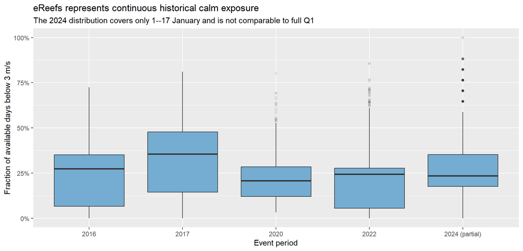

# eReefs versus Metop-B

Comparison is restricted to unique eReefs cells with at least 70% good-QC Metop coverage. The 2024 products are not compared because their time windows are different.

| Year | Cells | Mean Spearman | Mean RMSE | eReefs - Metop bias | Q10 Spearman | Calm-fraction Spearman |
| --- | --- | --- | --- | --- | --- | --- |
| 2016 | 1230 | 0.858 | 0.449 | -0.369 | 0.170 | 0.435 |
| 2017 | 1232 | 0.533 | 0.433 | -0.385 | 0.113 | 0.260 |
| 2020 | 1236 | -0.054 | 0.380 | -0.275 | 0.484 | 0.112 |
| 2022 | 1240 | 0.684 | 0.179 | -0.076 | -0.074 | 0.242 |

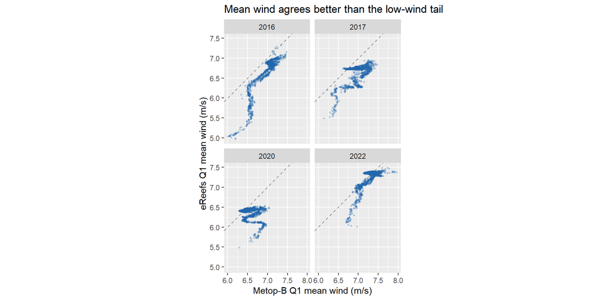

# Implementation recommendation

1. Preserve the extracted eReefs variables as historical sensitivity inputs: Q1 mean, Q10, minimum, fractions and days below 3/5 m/s, and longest calm spells. Do not label the 2024 record complete.
2. Preserve Sentinel-1 and Metop coverage fields and never interpret missing satellite pixels as calm conditions.
3. Use the completed AWS ERA5 extraction as the continuous source for formal modelling. Retain mean speed plus calm fraction below 3 m/s; keep Q10 and longest spells as sensitivity variables rather than adding all correlated metrics simultaneously.
4. Re-run the fixed outer validation folds before promoting wind into the production BRMS/BRT ensemble. The ecological hypothesis is strong, but the predictor still has to improve temporal transfer, severe-event error, or interval calibration.